# Machine Learning

Yen-Chu Tu

May 27, 2019

## Training and Testing Sets

The training set and testing set are loaded into the R environment, but the testing set it not yet examined. The libraries needed are also loaded. The data can be graphed against arm, belt, forearm, and dumbbell data to see if there’re any obvious correlations.

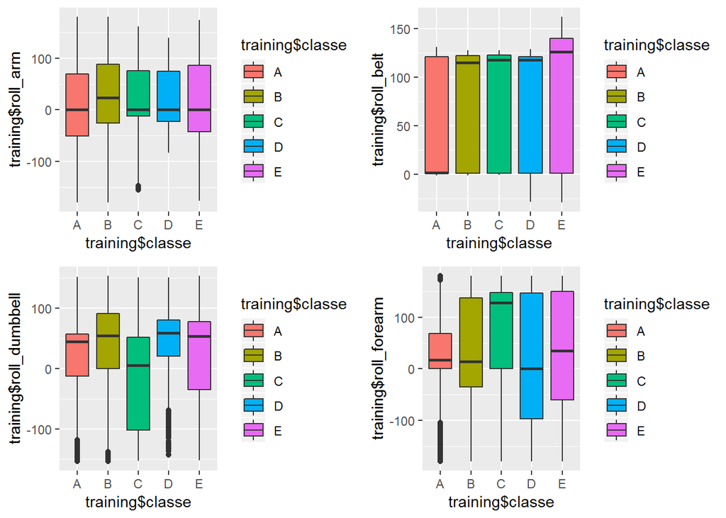

```r
library(caret); library(rattle); library(ggplot2);library(gridExtra)
training <- read.csv("./pml-training.csv")
testing <- read.csv("./pml-testing.csv")
p1 <- qplot(training$classe, training$roll_arm, data=training, fill=training$classe, geom=c("boxplot"))
p2 <- qplot(training$classe, training$roll_belt, data=training, fill=training$classe, geom=c("boxplot"))
p3 <- qplot(training$classe, training$roll_dumbbell, data=training, fill=training$classe, geom=c("boxplot"))
p4 <- qplot(training$classe, training$roll_forearm, data=training, fill=training$classe, geom=c("boxplot"))
grid.arrange(p1,p2,p3,p4,ncol=2, nrow=2)
```

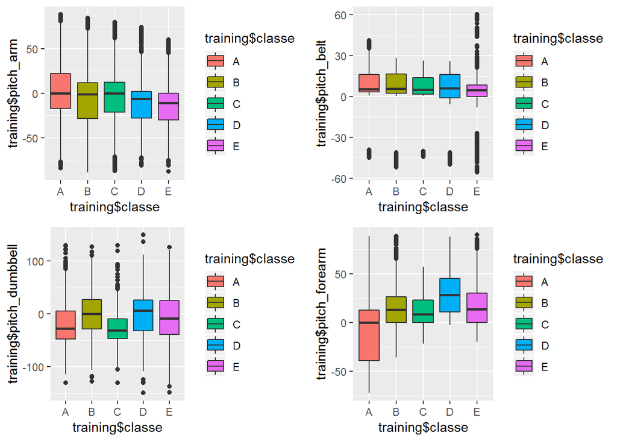

```r
p5 <- qplot(training$classe, training$pitch_arm, data=training, fill=training$classe, geom=c("boxplot"))
p6 <- qplot(training$classe, training$pitch_belt, data=training, fill=training$classe, geom=c("boxplot"))
p7 <- qplot(training$classe, training$pitch_dumbbell, data=training, fill=training$classe, geom=c("boxplot"))
p8 <- qplot(training$classe, training$pitch_forearm, data=training, fill=training$classe, geom=c("boxplot"))
grid.arrange(p5,p6,p7,p8,ncol=2, nrow=2)
```

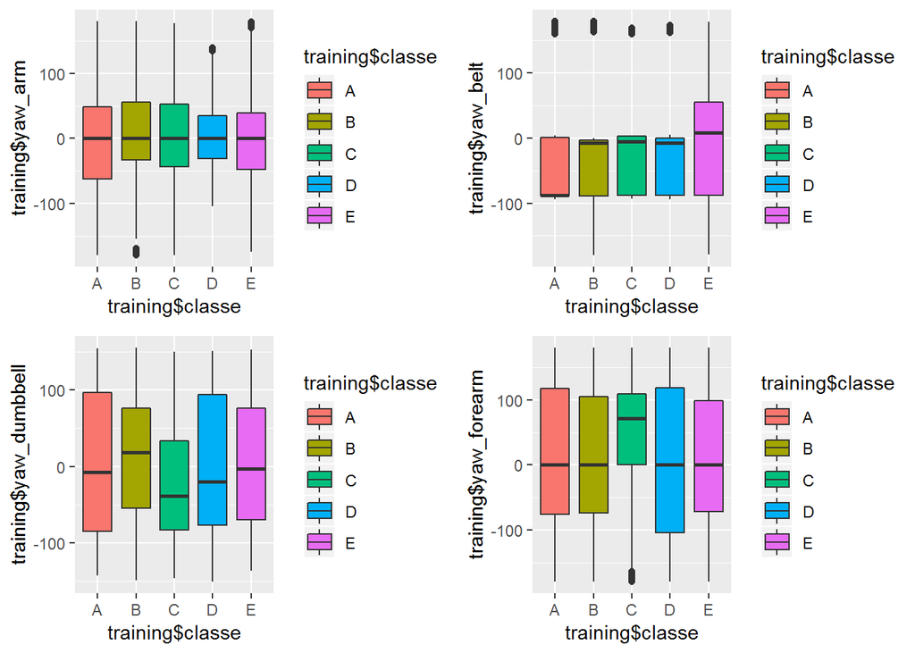

```r
p9 <- qplot(training$classe, training$yaw_arm, data=training, fill=training$classe, geom=c("boxplot"))
p10 <- qplot(training$classe, training$yaw_belt, data=training, fill=training$classe, geom=c("boxplot"))
p11 <- qplot(training$classe, training$yaw_dumbbell, data=training, fill=training$classe, geom=c("boxplot"))
p12 <- qplot(training$classe, training$yaw_forearm, data=training, fill=training$classe, geom=c("boxplot"))
grid.arrange(p9,p10,p11,p12,ncol=2, nrow=2)
```

From this data we can see that the data gathered by the arm does not help too much with the prediction of the classe. Therefore, the arm datas can be excluded from the analysis.

## Modeling

The first approach that was taken was the general linear model appraoch.

```r
fit <- train(classe~., method="glm", data=training)
```

However, the classe category is not a 2-class factor, and therefore the glm model does not work. Therefore, Our training set will be used to generate the model by predicting with trees.

First, the data must be edited to ensure that the incomplete datasets are excluded from the data analysis.

```r
columns <- match(colSums(is.na(training)),0)
columns[is.na(columns)]<-0
columns <- as.logical(columns)
trainset <- training[,columns]
testset <- testing[,columns]
```

Furthermore, from the summary of the data, we can see that the factor class data are extremely lopsided, with many data having a void value. therefore, factor class data are also excluded.

```r
finaltrainset <- trainset[, sapply(trainset, class) != "factor"]
finaltrainset <- cbind(finaltrainset, trainset[93])
names(finaltrainset)[57]<-"classe"
final <- finaltrainset[,c(-1,-2,-3,-4)]
final <- final[,c(-14:-26)]
```

### Preprocessing

The data can be preprocessed to eliminate variations.

```r
ppfinal <- preProcess(final[,-40], method=c("center", "scale"))
pptrain <- predict(ppfinal,final[,-40])
pptrainn <- cbind(pptrain, final[,40])
names(pptrainn)[40] <- "classe"
pptest <- predict(ppfinal,testing[,-160])
pptestt <- cbind(pptest, testing[,160])
names(pptestt)[160] <- "classe"
```

### Modelling

```r
fitsett <- train(classe~., method="rpart", data=pptrainn)
print(fitsett$finalModel)
```

```
## n= 19622
##
## node), split, n, loss, yval, (yprob)
##       * denotes terminal node
##
##  1) root 19622 14042 A (0.28 0.19 0.17 0.16 0.18)
##    2) roll_belt< 1.053267 17977 12411 A (0.31 0.21 0.19 0.18 0.11)
##      4) pitch_forearm< -1.58661 1578    10 A (0.99 0.0063 0 0 0) *
##      5) pitch_forearm>=-1.58661 16399 12401 A (0.24 0.23 0.21 0.2 0.12)
##       10) magnet_dumbbell_y< 0.6685762 13870  9953 A (0.28 0.18 0.24 0.19 0.11)
##         20) roll_forearm< 0.8300342 8643  5131 A (0.41 0.18 0.18 0.17 0.061) *
##         21) roll_forearm>=0.8300342 5227  3500 C (0.077 0.18 0.33 0.23 0.18) *
##       11) magnet_dumbbell_y>=0.6685762 2529  1243 B (0.032 0.51 0.043 0.22 0.19) *
##    3) roll_belt>=1.053267 1645    14 E (0.0085 0 0 0 0.99) *
```

[figure not shown]

```r
plot <- fancyRpartPlot(fitsett$finalModel)
```

## Cross Validation

For cross validation to estimate the out of sample error, we use K-Folds. First, we must shuffle the data, as the training set is ordered by classe.

```r
set.seed(31415)
trainrandom <- pptrainn[sample(nrow(pptrainn)),]
folds <- createFolds(y=trainrandom$classe, k=5, list=TRUE, returnTrain=TRUE)
```

The folds can be used to subset into the train function to find samples for cross validation.

```r
train1 <- trainrandom[folds$Fold1,]
train2 <- trainrandom[folds$Fold2,]
train3 <- trainrandom[folds$Fold3,]
train4 <- trainrandom[folds$Fold4,]
train5 <- trainrandom[folds$Fold5,]
```

The data can then be predicted by our model to test for each of the 5 folds to estimate the out of sample error rate.

```r
predict1 <- predict(fitsett, newdata=train1)
predict2 <- predict(fitsett, newdata=train2)
predict3 <- predict(fitsett, newdata=train3)
predict4 <- predict(fitsett, newdata=train4)
predict5 <- predict(fitsett, newdata=train5)
```

The error rate is calculated and then averaged across the 5 folds.

```r
rate1 <- table(predict1==train1$classe)[1]/length(predict1)
rate2 <- table(predict2==train2$classe)[1]/length(predict2)
rate3 <- table(predict3==train3$classe)[1]/length(predict3)
rate4 <- table(predict4==train4$classe)[1]/length(predict4)
rate5 <- table(predict5==train5$classe)[1]/length(predict5)
mean(c(rate1,rate2,rate3,rate4,rate5))
```

```
## [1] 0.5044338
```

## Testing

The predictions for the test set can be found using the predict function. The testing set has been loaded at the beginning of the analysis.

```r
predict(fitsett, newdata=pptestt)
```

```
##  [1] C A C A A C C A A A C C C A C A A A A C
## Levels: A B C D E
```